# Part I - (FordGoBike Data Analysis)

## by (Okeri Mwikali Josephine)

## Introduction

> This data set consist of 183 000 rides made in a bike-sharing system covering the greater San Francisco Bay area. The dataset include the following features rider duration, Stations, time, gender of the rider and also user type.

## Preliminary Wrangling

```python
# import all packages and set plots to be embedded inline
import numpy as np
import pandas as pd
import matplotlib.pyplot as plt
import seaborn as sb

%matplotlib inline
import warnings
warnings.filterwarnings('ignore')
```

```python
# loading data
df_bike=pd.read_csv('201902-fordgobike-tripdata.csv')
```

```python
#checking shape and data types
print(df_bike.shape)
print(df_bike.dtypes)
df_bike.head(10)
```

```
(183412, 16)
duration_sec                 int64
start_time                  object
end_time                    object
start_station_id           float64
start_station_name          object
start_station_latitude     float64
start_station_longitude    float64
end_station_id             float64
end_station_name            object
end_station_latitude       float64
end_station_longitude      float64
bike_id                      int64
user_type                   object
member_birth_year          float64
member_gender               object
bike_share_for_all_trip     object
dtype: object
```

|  | duration_sec | start_time | end_time | start_station_id | start_station_name | start_station_latitude | start_station_longitude | end_station_id | end_station_name | end_station_latitude | end_station_longitude | bike_id | user_type | member_birth_year | member_gender | bike_share_for_all_trip |
| --- | --- | --- | --- | --- | --- | --- | --- | --- | --- | --- | --- | --- | --- | --- | --- | --- |
| 0 | 52185 | 2019-02-28 17:32:10.1450 | 2019-03-01 08:01:55.9750 | 21.0 | Montgomery St BART Station (Market St at 2nd St) | 37.789625 | -122.400811 | 13.0 | Commercial St at Montgomery St | 37.794231 | -122.402923 | 4902 | Customer | 1984.0 | Male | No |
| 1 | 42521 | 2019-02-28 18:53:21.7890 | 2019-03-01 06:42:03.0560 | 23.0 | The Embarcadero at Steuart St | 37.791464 | -122.391034 | 81.0 | Berry St at 4th St | 37.775880 | -122.393170 | 2535 | Customer | NaN | NaN | No |
| 2 | 61854 | 2019-02-28 12:13:13.2180 | 2019-03-01 05:24:08.1460 | 86.0 | Market St at Dolores St | 37.769305 | -122.426826 | 3.0 | Powell St BART Station (Market St at 4th St) | 37.786375 | -122.404904 | 5905 | Customer | 1972.0 | Male | No |
| 3 | 36490 | 2019-02-28 17:54:26.0100 | 2019-03-01 04:02:36.8420 | 375.0 | Grove St at Masonic Ave | 37.774836 | -122.446546 | 70.0 | Central Ave at Fell St | 37.773311 | -122.444293 | 6638 | Subscriber | 1989.0 | Other | No |
| 4 | 1585 | 2019-02-28 23:54:18.5490 | 2019-03-01 00:20:44.0740 | 7.0 | Frank H Ogawa Plaza | 37.804562 | -122.271738 | 222.0 | 10th Ave at E 15th St | 37.792714 | -122.248780 | 4898 | Subscriber | 1974.0 | Male | Yes |
| 5 | 1793 | 2019-02-28 23:49:58.6320 | 2019-03-01 00:19:51.7600 | 93.0 | 4th St at Mission Bay Blvd S | 37.770407 | -122.391198 | 323.0 | Broadway at Kearny | 37.798014 | -122.405950 | 5200 | Subscriber | 1959.0 | Male | No |
| 6 | 1147 | 2019-02-28 23:55:35.1040 | 2019-03-01 00:14:42.5880 | 300.0 | Palm St at Willow St | 37.317298 | -121.884995 | 312.0 | San Jose Diridon Station | 37.329732 | -121.901782 | 3803 | Subscriber | 1983.0 | Female | No |
| 7 | 1615 | 2019-02-28 23:41:06.7660 | 2019-03-01 00:08:02.7560 | 10.0 | Washington St at Kearny St | 37.795393 | -122.404770 | 127.0 | Valencia St at 21st St | 37.756708 | -122.421025 | 6329 | Subscriber | 1989.0 | Male | No |
| 8 | 1570 | 2019-02-28 23:41:48.7900 | 2019-03-01 00:07:59.7150 | 10.0 | Washington St at Kearny St | 37.795393 | -122.404770 | 127.0 | Valencia St at 21st St | 37.756708 | -122.421025 | 6548 | Subscriber | 1988.0 | Other | No |
| 9 | 1049 | 2019-02-28 23:49:47.6990 | 2019-03-01 00:07:17.0250 | 19.0 | Post St at Kearny St | 37.788975 | -122.403452 | 121.0 | Mission Playground | 37.759210 | -122.421339 | 6488 | Subscriber | 1992.0 | Male | No |

```python
#To check descriptive statistic of numeric values
df_bike.describe()
```

|  | duration_sec | start_station_id | start_station_latitude | start_station_longitude | end_station_id | end_station_latitude | end_station_longitude | bike_id | member_birth_year |
| --- | --- | --- | --- | --- | --- | --- | --- | --- | --- |
| count | 183412.000000 | 183215.000000 | 183412.000000 | 183412.000000 | 183215.000000 | 183412.000000 | 183412.000000 | 183412.000000 | 175147.000000 |
| mean | 726.078435 | 138.590427 | 37.771223 | -122.352664 | 136.249123 | 37.771427 | -122.352250 | 4472.906375 | 1984.806437 |
| std | 1794.389780 | 111.778864 | 0.099581 | 0.117097 | 111.515131 | 0.099490 | 0.116673 | 1664.383394 | 10.116689 |
| min | 61.000000 | 3.000000 | 37.317298 | -122.453704 | 3.000000 | 37.317298 | -122.453704 | 11.000000 | 1878.000000 |
| 25% | 325.000000 | 47.000000 | 37.770083 | -122.412408 | 44.000000 | 37.770407 | -122.411726 | 3777.000000 | 1980.000000 |
| 50% | 514.000000 | 104.000000 | 37.780760 | -122.398285 | 100.000000 | 37.781010 | -122.398279 | 4958.000000 | 1987.000000 |
| 75% | 796.000000 | 239.000000 | 37.797280 | -122.286533 | 235.000000 | 37.797320 | -122.288045 | 5502.000000 | 1992.000000 |
| max | 85444.000000 | 398.000000 | 37.880222 | -121.874119 | 398.000000 | 37.880222 | -121.874119 | 6645.000000 | 2001.000000 |

```python
# Checking data columns
df_bike.columns
```

```
Index(['duration_sec', 'start_time', 'end_time', 'start_station_id',
       'start_station_name', 'start_station_latitude',
       'start_station_longitude', 'end_station_id', 'end_station_name',
       'end_station_latitude', 'end_station_longitude', 'bike_id', 'user_type',
       'member_birth_year', 'member_gender', 'bike_share_for_all_trip'],
      dtype='object')
```

```python
# Checking missing values
df_bike.isna().sum()
```

```
duration_sec                  0
start_time                    0
end_time                      0
start_station_id            197
start_station_name          197
start_station_latitude        0
start_station_longitude       0
end_station_id              197
end_station_name            197
end_station_latitude          0
end_station_longitude         0
bike_id                       0
user_type                     0
member_birth_year          8265
member_gender              8265
bike_share_for_all_trip       0
dtype: int64
```

### Issue

- Missing Values on start_station_id ,start_station_name,end_station_id,end_station_name,member_birth_year and member_gender
- Start_time and End_time have wrong data types as object
- Bike_id wrong data type
- Extract Hour, day and month from the start_time and end_time

```python
# Make a copy of original data
df_bike_clean=df_bike.copy()
```

### 1. Missing Values on start_station_id ,start_station_name,end_station_id,end_station_name,member_birth_year and member_gender

#### Define: Removing all the rows of missing Value

#### Code

```python
#Dropping the rows with missing values
df_bike_clean.dropna(inplace=True)
```

### Test

```python
df_bike_clean.isna().sum()
```

```
duration_sec               0
start_time                 0
end_time                   0
start_station_id           0
start_station_name         0
start_station_latitude     0
start_station_longitude    0
end_station_id             0
end_station_name           0
end_station_latitude       0
end_station_longitude      0
bike_id                    0
user_type                  0
member_birth_year          0
member_gender              0
bike_share_for_all_trip    0
dtype: int64
```

### 2.Start_time and End_time have wrong data types as object

#### Define: Change the data type of start_time and End_time to datetime

#### Code

```python
df_bike_clean.start_time=pd.to_datetime(df_bike_clean.start_time)
df_bike_clean.end_time=pd.to_datetime(df_bike_clean.end_time)
```

```python
print(df_bike_clean.dtypes)
```

```
duration_sec                        int64
start_time                 datetime64[ns]
end_time                   datetime64[ns]
start_station_id                  float64
start_station_name                 object
start_station_latitude            float64
start_station_longitude           float64
end_station_id                    float64
end_station_name                   object
end_station_latitude              float64
end_station_longitude             float64
bike_id                             int64
user_type                          object
member_birth_year                 float64
member_gender                      object
bike_share_for_all_trip            object
dtype: object
```

### 2.Bike_id have wrong data types as int

#### Define: Change the data type of bike_id to string

#### Code

```python
df_bike_clean.bike_id=df_bike_clean.bike_id.astype(str)
```

```python
df_bike_clean.info()
```

```
<class 'pandas.core.frame.DataFrame'>
Int64Index: 174952 entries, 0 to 183411
Data columns (total 16 columns):
duration_sec               174952 non-null int64
start_time                 174952 non-null datetime64[ns]
end_time                   174952 non-null datetime64[ns]
start_station_id           174952 non-null float64
start_station_name         174952 non-null object
start_station_latitude     174952 non-null float64
start_station_longitude    174952 non-null float64
end_station_id             174952 non-null float64
end_station_name           174952 non-null object
end_station_latitude       174952 non-null float64
end_station_longitude      174952 non-null float64
bike_id                    174952 non-null object
user_type                  174952 non-null object
member_birth_year          174952 non-null float64
member_gender              174952 non-null object
bike_share_for_all_trip    174952 non-null object
dtypes: datetime64[ns](2), float64(7), int64(1), object(6)
memory usage: 22.7+ MB
```

### Issue 4. The start_time and end_time contain hour, day and month information

### Define. Extract Hour, day and month from the start_time and End_time

### Code

```python
import datetime as dt
df_bike_clean['start_hour']=df_bike_clean['start_time'].dt.hour
df_bike_clean.start_hour=df_bike_clean.start_hour.astype(str)
df_bike_clean['start_day']=df_bike_clean['start_time'].dt.day_name()
df_bike_clean['start_month']=df_bike_clean['start_time'].dt.month_name()

df_bike_clean['end_hour']=df_bike_clean['end_time'].dt.hour
df_bike_clean.end_hour=df_bike_clean.end_hour.astype(str)
df_bike_clean['end_day']=df_bike_clean['end_time'].dt.day_name()
df_bike_clean['end_month']=df_bike_clean['end_time'].dt.month_name()
```

```python
#Test
df_bike_clean.head(5)
print(df_bike_clean.shape)
df_bike_clean.head(10)
```

```
(174952, 22)
```

|  | duration_sec | start_time | end_time | start_station_id | start_station_name | start_station_latitude | start_station_longitude | end_station_id | end_station_name | end_station_latitude | ... | user_type | member_birth_year | member_gender | bike_share_for_all_trip | start_hour | start_day | start_month | end_hour | end_day | end_month |
| --- | --- | --- | --- | --- | --- | --- | --- | --- | --- | --- | --- | --- | --- | --- | --- | --- | --- | --- | --- | --- | --- |
| 0 | 52185 | 2019-02-28 17:32:10.145 | 2019-03-01 08:01:55.975 | 21.0 | Montgomery St BART Station (Market St at 2nd St) | 37.789625 | -122.400811 | 13.0 | Commercial St at Montgomery St | 37.794231 | ... | Customer | 1984.0 | Male | No | 17 | Thursday | February | 8 | Friday | March |
| 2 | 61854 | 2019-02-28 12:13:13.218 | 2019-03-01 05:24:08.146 | 86.0 | Market St at Dolores St | 37.769305 | -122.426826 | 3.0 | Powell St BART Station (Market St at 4th St) | 37.786375 | ... | Customer | 1972.0 | Male | No | 12 | Thursday | February | 5 | Friday | March |
| 3 | 36490 | 2019-02-28 17:54:26.010 | 2019-03-01 04:02:36.842 | 375.0 | Grove St at Masonic Ave | 37.774836 | -122.446546 | 70.0 | Central Ave at Fell St | 37.773311 | ... | Subscriber | 1989.0 | Other | No | 17 | Thursday | February | 4 | Friday | March |
| 4 | 1585 | 2019-02-28 23:54:18.549 | 2019-03-01 00:20:44.074 | 7.0 | Frank H Ogawa Plaza | 37.804562 | -122.271738 | 222.0 | 10th Ave at E 15th St | 37.792714 | ... | Subscriber | 1974.0 | Male | Yes | 23 | Thursday | February | 0 | Friday | March |
| 5 | 1793 | 2019-02-28 23:49:58.632 | 2019-03-01 00:19:51.760 | 93.0 | 4th St at Mission Bay Blvd S | 37.770407 | -122.391198 | 323.0 | Broadway at Kearny | 37.798014 | ... | Subscriber | 1959.0 | Male | No | 23 | Thursday | February | 0 | Friday | March |
| 6 | 1147 | 2019-02-28 23:55:35.104 | 2019-03-01 00:14:42.588 | 300.0 | Palm St at Willow St | 37.317298 | -121.884995 | 312.0 | San Jose Diridon Station | 37.329732 | ... | Subscriber | 1983.0 | Female | No | 23 | Thursday | February | 0 | Friday | March |
| 7 | 1615 | 2019-02-28 23:41:06.766 | 2019-03-01 00:08:02.756 | 10.0 | Washington St at Kearny St | 37.795393 | -122.404770 | 127.0 | Valencia St at 21st St | 37.756708 | ... | Subscriber | 1989.0 | Male | No | 23 | Thursday | February | 0 | Friday | March |
| 8 | 1570 | 2019-02-28 23:41:48.790 | 2019-03-01 00:07:59.715 | 10.0 | Washington St at Kearny St | 37.795393 | -122.404770 | 127.0 | Valencia St at 21st St | 37.756708 | ... | Subscriber | 1988.0 | Other | No | 23 | Thursday | February | 0 | Friday | March |
| 9 | 1049 | 2019-02-28 23:49:47.699 | 2019-03-01 00:07:17.025 | 19.0 | Post St at Kearny St | 37.788975 | -122.403452 | 121.0 | Mission Playground | 37.759210 | ... | Subscriber | 1992.0 | Male | No | 23 | Thursday | February | 0 | Friday | March |
| 10 | 458 | 2019-02-28 23:57:57.211 | 2019-03-01 00:05:35.435 | 370.0 | Jones St at Post St | 37.787327 | -122.413278 | 43.0 | San Francisco Public Library (Grove St at Hyde... | 37.778768 | ... | Subscriber | 1996.0 | Female | Yes | 23 | Thursday | February | 0 | Friday | March |

10 rows × 22 columns

### What is the structure of your dataset?

> The data had 183412 rows and 16 columns after cleaning and removing rows with missing values our new row become 174952 and after extracting some information our new column become 22.

### What is/are the main feature(s) of interest in your dataset?

> Trip Duration

### What features in the dataset do you think will help support your investigation into your feature(s) of interest?

> Hours of the day, Days of the week and User Type

## Univariate Exploration

### Is the duration_sec distribution unimodal or Multimodal?

```python
def myplot(x,y,t):
    """
    arg:
    x:x-axis
    y:y_axis
    t:graph title
    Return:
    None
    """
    plt.xlabel(x)
    plt.ylabel(y)
    plt.title(t)
    color=sb.color_palette()[2]
    plt.show()
```

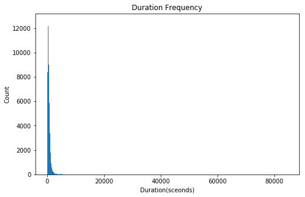

```python
binsize=50
bins=np.arange(50,df_bike_clean['duration_sec'].max()+binsize,binsize)
plt.figure(figsize=[8,5])
plt.hist(data=df_bike_clean,x='duration_sec', bins=bins)
myplot("Duration(sceonds)","Count","Duration Frequency")
```

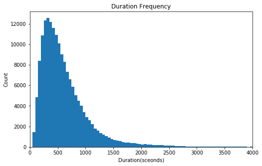

```python
binsize=50
bins=np.arange(50,df_bike_clean['duration_sec'].max()+binsize,binsize)
plt.figure(figsize=[8,5])
plt.xlim(0,4000)
plt.hist(data=df_bike_clean,x='duration_sec', bins=bins)
myplot("Duration(sceonds)","Count","Duration Frequency")
```

The Frequency graph is unimodal

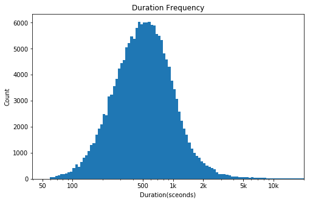

```python
log_binsize=0.025
bins=10**np.arange(1.6, np.log10(df_bike_clean['duration_sec'].max())+log_binsize,log_binsize)
plt.figure(figsize=[8,5])
plt.hist(data=df_bike_clean,x='duration_sec', bins=bins)
plt.xscale('log')
plt.xticks([50,100,500,1e3,2e3,5e3,1e4,2e5],[50,100,500,'1k','2k','5k','10k','20k'])
plt.xlim(0,20000)
myplot("Duration(sceonds)","Count","Duration Frequency")
```

### Discuss the distribution(s) of your variable(s) of interest. Were there any unusual points? Did you need to perform any transformations?

> First there was a long tail in the distribution after log scale the distribution is unimodal and has a short duration trip between 70-100.and long duration from 1000. we have peak at 500 seconds and we have few long trips more than 2000 seconds

### Of the features you investigated, were there any unusual distributions? Did you perform any operations on the data to tidy, adjust, or change the form of the data? If so, why did you do this?

> Yes their was long tail in the distribution, then i applied logscale in the data transformed data

```
(-1.1073121887520356,
 1.107227178965096,
 -1.1054688582560726,
 1.1090705094610591)
```

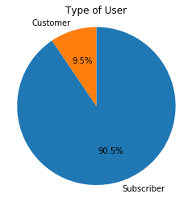

```python
# Rider Count per user Type
user_type_counts=df_bike_clean.user_type.value_counts()
plt.pie(user_type_counts,labels=user_type_counts.index, autopct='%1.1f%%',startangle=90,counterclock=False);
plt.title('Type of User')
plt.axis('square')
```

Most of the rider are the subscriber users with 90.5% while customersare few with 9.5 %

```
(-1.1072592340323726,
 1.1203835586186992,
 -1.1199361631365747,
 1.1077066295144971)
```

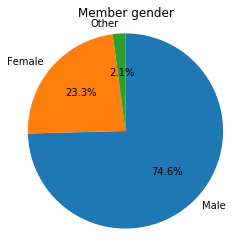

```python
#Rider count according to gender
member_gender_counts=df_bike_clean.member_gender.value_counts()
plt.pie(member_gender_counts,labels=member_gender_counts.index, autopct='%1.1f%%',startangle=90,counterclock=False);
plt.title('Member gender')
plt.axis('square')
```

Most riders were male with 74.6% and Female with 23.3% and other come last 2.1%

```
(-1.1076152401250434,
 1.1068950535821704,
 -1.1043090134150371,
 1.1102012802921768)
```

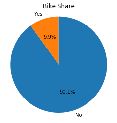

```python
#plotting pie chart for bike share
bike_share_counts=df_bike_clean.bike_share_for_all_trip.value_counts()
plt.pie(bike_share_counts,labels=bike_share_counts.index, autopct='%1.1f%%',startangle=90,counterclock=False);
plt.title('Bike Share')
plt.axis('square')
```

Most riders do not share bike with 90.1% and those share bike were 9.9%

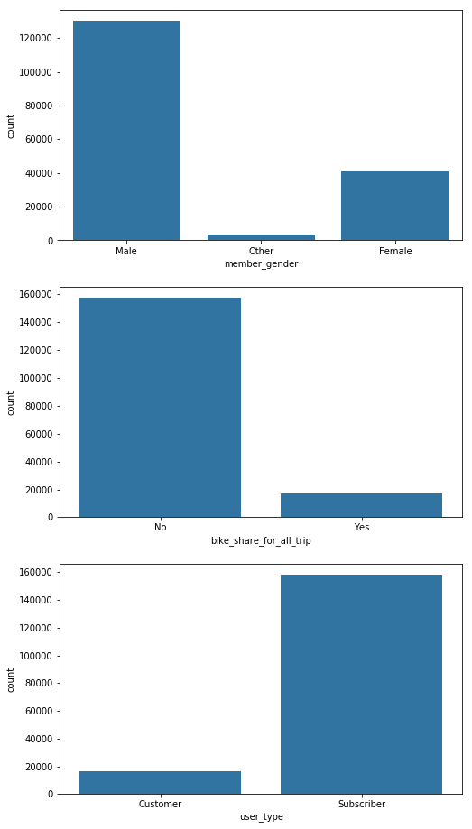

```python
#Frequency for bike share in all trip
# Member gender,user type
fig,ax=plt.subplots(nrows=3,figsize=[8,16])
default_color=sb.color_palette()[0]
sb.countplot(data=df_bike_clean,x='member_gender',color=default_color,ax=ax[0])
sb.countplot(data=df_bike_clean,x='bike_share_for_all_trip',color=default_color,ax=ax[1])
sb.countplot(data=df_bike_clean,x='user_type',color=default_color,ax=ax[2])
plt.show()
```

```python
# convert day, and hour into categorical types
day_hour_class = {'start_day': ['Monday','Tuesday','Wednesday','Thursday','Friday', 'Saturday', 'Sunday'],
                    'end_day': ['Monday','Tuesday','Wednesday','Thursday','Friday', 'Saturday', 'Sunday'],
                   'start_hour': [str(i) for i in range(0,24)],
                   'end_hour': [str(i) for i in range(0,24)]}

for var in day_hour_class:
    dhclass = pd.api.types.CategoricalDtype(ordered = True, categories = day_hour_class[var])
    df_bike_clean[var] = df_bike_clean[var].astype(dhclass)
```

### How many trips in a week

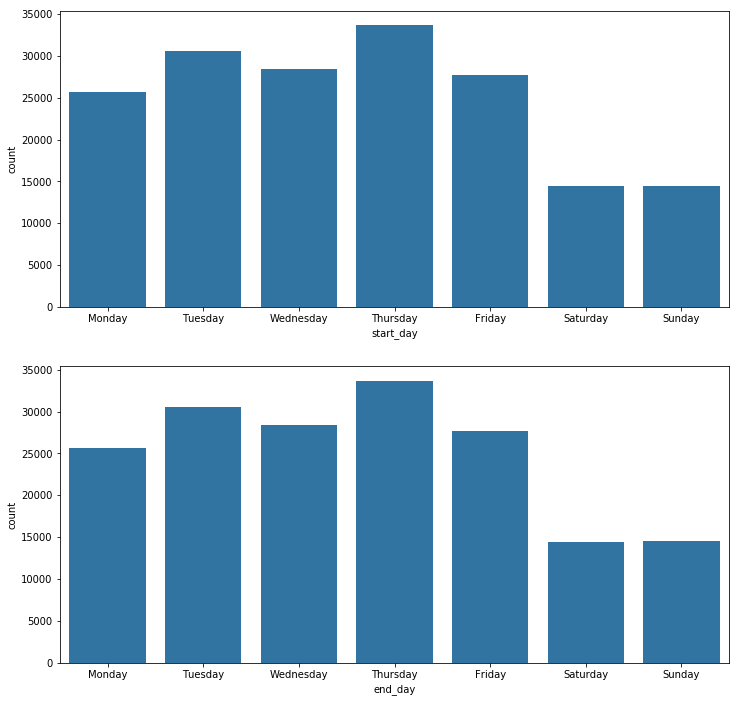

```python
# ride frequency per days
fig, ax = plt.subplots(2, figsize = [12,12])
default_color = sb.color_palette()[0]
sb.countplot(data = df_bike_clean, x = 'start_day', color = default_color,  ax = ax[0])
sb.countplot(data = df_bike_clean, x = 'end_day', color = default_color,  ax = ax[1])
```

Most trips are on weekdays and thursday having the high number of trips. On weekends trip are low(saturday and sunday)

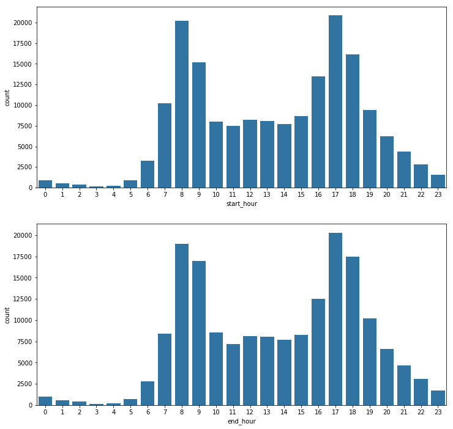

```python
# ride frequency per hours
fig, ax = plt.subplots(2,figsize = [12,12])
default_color = sb.color_palette()[0]
sb.countplot(data = df_bike_clean, x = 'start_hour', color = default_color,  ax = ax[0])
sb.countplot(data =df_bike_clean, x = 'end_hour', color = default_color, ax = ax[1])
```

Most trips start at 8th,9th,16th,17th,18th hour with highest rides and few rides from 0 to 5th hour

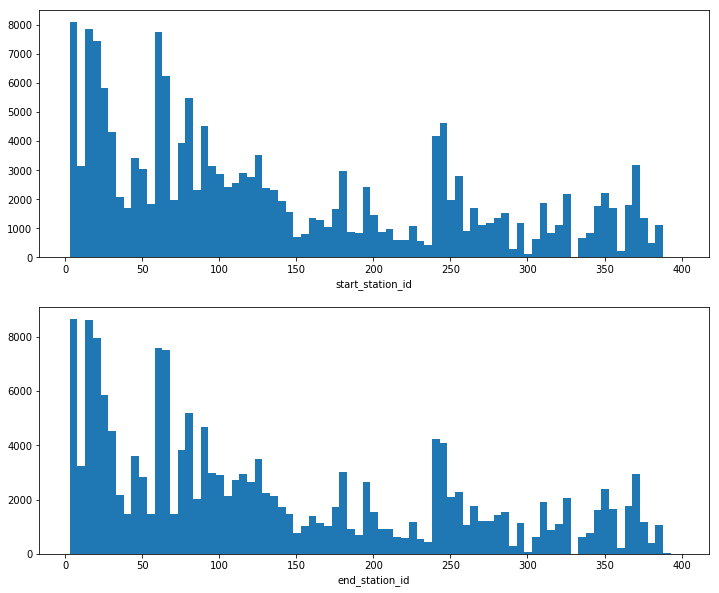

```python
# plotting start and end stations id
fig,ax=plt.subplots(nrows=2, figsize=[12,10])
variables=['start_station_id','end_station_id']
for i in range(len(variables)):
    var=variables[i]
    bins=np.arange(min(df_bike_clean[var]),max(df_bike_clean[var])+5,5)
    ax[i].hist(data=df_bike_clean,x=var,bins=bins)
    ax[i].set_xlabel('{}'.format(var))
plt.show()
```

Some stations are recordig same number in the start and end of station trend looks similar

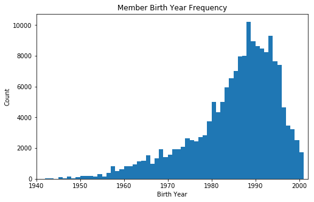

```python
#plotting member birth distribution
binsize =1
bins = np.arange(0, df_bike_clean['member_birth_year'].max()+binsize, binsize)

plt.figure(figsize=[8, 5])
plt.hist(data = df_bike_clean, x = 'member_birth_year', bins = bins)
plt.xlim([1940,2002])
myplot("Birth Year","Count","Member Birth Year Frequency")
```

Most rides were born in 1985 to 1995

## Bivariate Exploration

```python
numeric_vars = ['duration_sec','start_station_id','end_station_id','member_birth_year']
categoric_vars = ['user_type','member_gender','bike_share_for_all_trip','start_day','end_day','start_hour','end_hour']
```

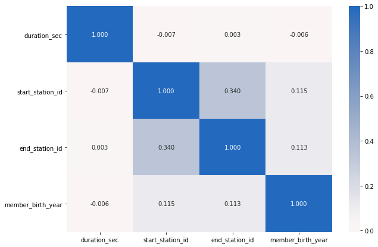

```python
# correlation plot
plt.figure(figsize = [10, 7])
sb.heatmap(df_bike_clean[numeric_vars].corr(), annot = True, fmt = '.3f',
           cmap = 'vlag_r', center = 0)
plt.show()
```

From the correlation plot we can clearly see that numeric variables are not much related

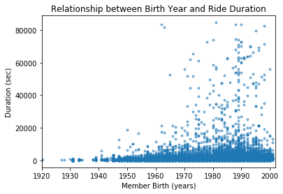

```python
#Relationship between Year of birh and Rider duration
plt.scatter(df_bike_clean['member_birth_year'], df_bike_clean['duration_sec'], alpha =0.5, marker = '.' )
plt.xlim(1920,2002)
myplot("Member Birth (years)","Duration (sec)","Relationship between Birth Year and Ride Duration")
```

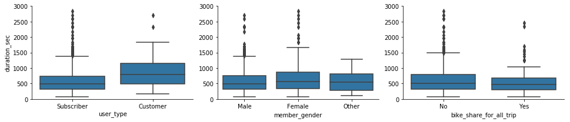

```python
#plotting duration against the three categorical variable
bikes_samp = df_bike_clean.sample(n=1000, replace = False)
def boxgrid(x,y,**kwargs):
    default_color=sb.color_palette()[0]
    sb.boxplot(x=x,y=y, color=default_color)
plt.figure(figsize=[10,10])
g=sb.PairGrid(data=bikes_samp, y_vars='duration_sec', x_vars=['user_type','member_gender','bike_share_for_all_trip'],size=3, aspect=1.5)
g.map(boxgrid)
plt.ylim([0,3000])
plt.show()
```

We can see that customers on the user type cover long distance although they had less total count compared to subscribers compared to bike share and the gender.

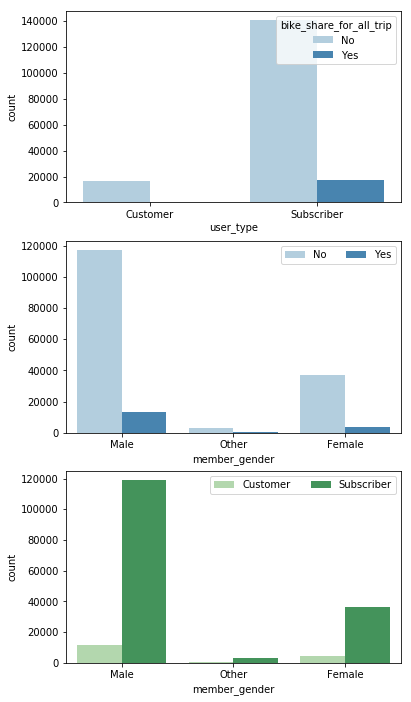

```python
# creating categorical three subplots , using the full data should be fine.
plt.figure(figsize = [6,12])

# subplot 1: user type vs. bike share
plt.subplot(3, 1, 1)
sb.countplot(data = df_bike_clean, x = 'user_type', hue = 'bike_share_for_all_trip', palette = 'Blues')

# subplot 2: member gender vs. bike share
ax = plt.subplot(3, 1, 2)
sb.countplot(data = df_bike_clean, x = 'member_gender', hue = 'bike_share_for_all_trip', palette = 'Blues')
ax.legend(ncol = 2) # re-arrange legend to reduce overlapping

# subplot 3: member gender vs. user type, use different color palette
ax = plt.subplot(3, 1, 3)
sb.countplot(data = df_bike_clean, x = 'member_gender', hue = 'user_type', palette = 'Greens')
ax.legend(loc = 1, ncol = 2) # re-arrange legend to remove overlapping

plt.show()
```

Customers didn't share bike compared to subscriber share their bike,also most subscriber did not share the bike. Most male did not share their bike recorded high count but comparing with the other gender it show most male share their bike while the other group of gender come last. Most male who ride the bike were subscribers.

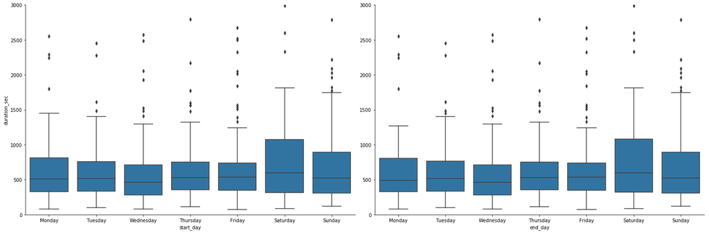

```python
#plotting Duration against start and end day
bikes_samp = df_bike_clean.sample(n=1000, replace = False)
def boxgrid(x,y,**kwargs):
    default_color=sb.color_palette()[0]
    sb.boxplot(x=x,y=y, color=default_color)
plt.figure(figsize=[10,10])
g=sb.PairGrid(data=bikes_samp, y_vars='duration_sec', x_vars=['start_day','end_day'],size=7, aspect=1.5)
g.map(boxgrid)
plt.ylim([0,3000])
plt.show()
```

weekends recorded lond distance trips both on start day and end day(saturdaya and sunday

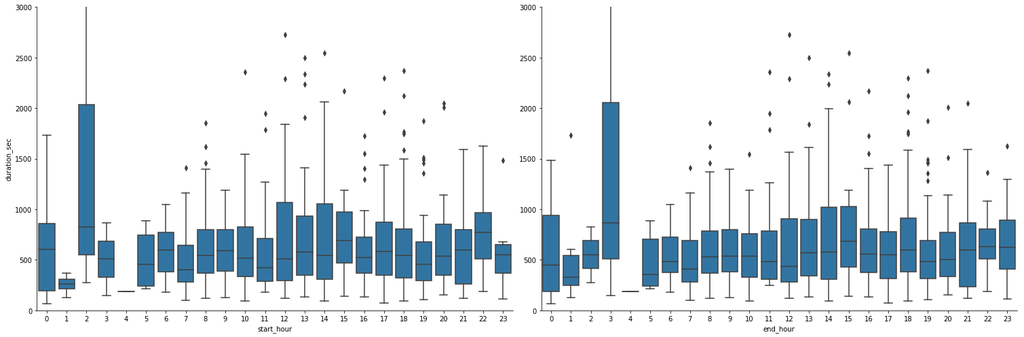

```python
bikes_samp = df_bike_clean.sample(n=1000, replace = False)
def boxgrid(x,y,**kwargs):
    default_color=sb.color_palette()[0]
    sb.boxplot(x=x,y=y, color=default_color)
plt.figure(figsize=[10,10])
g=sb.PairGrid(data=bikes_samp, y_vars='duration_sec', x_vars=['start_hour','end_hour'],size=7, aspect=1.5)
g.map(boxgrid)
plt.ylim([0,3000])
plt.show()
```

### Did you observe any interesting relationships between the other features (not the main feature(s) of interest)?

Most male who ride the bike were subscribers. Only subscribers were allowed to share their bike Most male did not share their bike recorded high count but comparing with the other gender it show most male share their bike while the other group of gender come last.

## Multivariate Exploration

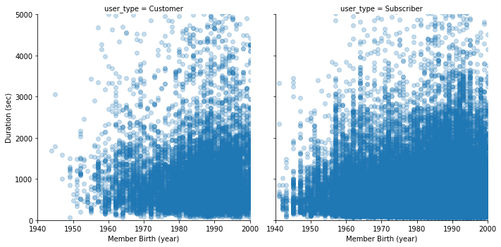

```python
#ploting relationship of user type in birth year and duration
g = sb.FacetGrid(data = df_bike_clean, col = 'user_type', col_wrap = 2, size = 5,
                 xlim = [1940, 2000], ylim = [0, 5000])
g.map(plt.scatter, 'member_birth_year', 'duration_sec', alpha=0.25)
g.set_xlabels('Member Birth (year)')
g.set_ylabels('Duration (sec)')

plt.show()
```

There is some strong relationship between young people born on 1970 up to 2000 for subscribers compared to customers

```python
def myplot1(y,title):
    plt.title(title)
    plt.ylabel(y)
    ax.set_yticklabels([],minor = True)
    plt.show()
```

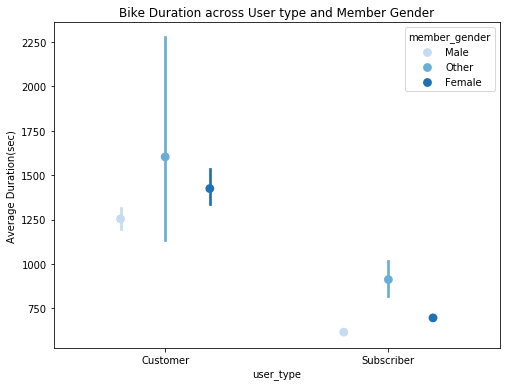

```python
# plotting of duration against user type and gender
fig = plt.figure(figsize = [8,6])
ax = sb.pointplot(data = df_bike_clean, x = 'user_type', y = 'duration_sec', hue = 'member_gender',
           palette = 'Blues', linestyles = '', dodge = 0.4)
myplot1("Average Duration(sec)","Bike Duration across User type and Member Gender")
```

customer who are in other group of gender travel long distances than subscribers followed by Female then male come last.

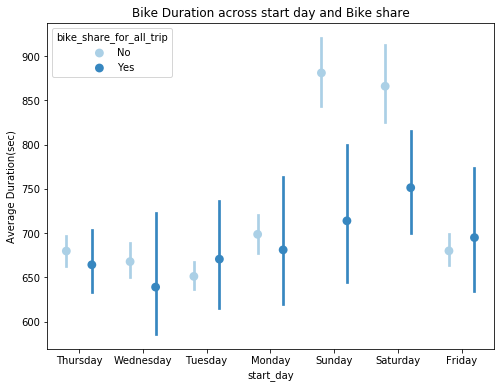

```python
# plotting of duration against start day and bike share
fig = plt.figure(figsize = [8,6])
ax = sb.pointplot(data = df_bike_clean, x = 'start_day', y = 'duration_sec', hue = 'bike_share_for_all_trip',
           palette = 'Blues', linestyles = '', dodge = 0.4)
myplot1("Average Duration(sec)","Bike Duration across start day and Bike share")
```

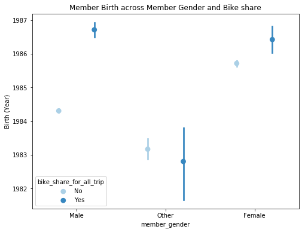

```python
# plotting of mebers Birth against usbike share and gender
fig = plt.figure(figsize = [8,6])
ax = sb.pointplot(data = df_bike_clean, x = 'member_gender', y = 'member_birth_year', hue = 'bike_share_for_all_trip',
           palette = 'Blues', linestyles = '', dodge = 0.4)
myplot1("Birth (Year)","Member Birth across Member Gender and Bike share")
```

The other gender that share bike most were born between 1982 and 1984.

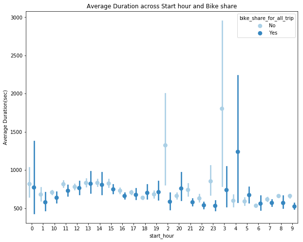

```python
# plotting of duration against start hour and bike share
fig = plt.figure(figsize = [10,8])
ax = sb.pointplot(data = df_bike_clean, x = 'start_hour', y = 'duration_sec', hue = 'bike_share_for_all_trip',
           palette = 'Blues', linestyles = '', dodge = 0.4)
myplot1("Average Duration(sec)","Average Duration across Start hour and Bike share")
```

At 2nd and 3rd hour no bike share for long distance, on 0 and 4th hour we have bike sharing for long distance recorded.

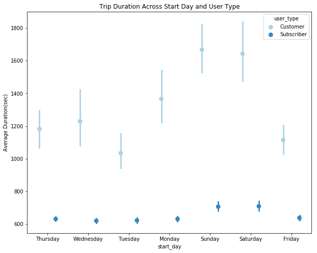

```python
# plotting of duration against user type and start day
fig = plt.figure(figsize = [10,8])
ax = sb.pointplot(data = df_bike_clean, x = 'start_day', y = 'duration_sec', hue = 'user_type',
           palette = 'Blues', linestyles = '', dodge = 0.4)
myplot1("Average Duration(sec)","Trip Duration Across Start Day and User Type")
```

### Were there any interesting or surprising interactions between features?

Though subscribers recorded high percentage on count they did not cover long duration trips as the customers. I was expecting that because most male had high percentage count to also have high bike ride duration but we found that other gender and most female had long trip durations.